chapter 10 数据表达与特征工程

# 数据表达

## 使用哑变量转化类型特征

```python
# 导入 pandas
import pandas as pd
fruits = pd.DataFrame({"value":[5,6,7,8,9],
                      "type":["waterMelon", "banana", "orange", "apple", "grape"]})
display(fruits)
```

|  | value | type |
| --- | --- | --- |
| 0 | 5 | waterMelon |
| 1 | 6 | banana |
| 2 | 7 | orange |
| 3 | 8 | apple |
| 4 | 9 | grape |

```python
# 转化数据表中的字符串为数值
fruits_dum=pd.get_dummies(fruits)
fruits_dum

# 数值列并没有变化，分类列变成了0-1矩阵
```

|  | value | type_apple | type_banana | type_grape | type_orange | type_waterMelon |
| --- | --- | --- | --- | --- | --- | --- |
| 0 | 5 | 0 | 0 | 0 | 0 | 1 |
| 1 | 6 | 0 | 1 | 0 | 0 | 0 |
| 2 | 7 | 0 | 0 | 0 | 1 | 0 |
| 3 | 8 | 1 | 0 | 0 | 0 | 0 |
| 4 | 9 | 0 | 0 | 1 | 0 | 0 |

```python
# 令程序将数值也看做字符串
fruits["value"] = fruits["value"].astype(str) #先将数值转为字符串，这一句可选，但是推荐加上。
# 用 get_dummies 转化为字符串
pd.get_dummies(fruits, columns=["value"])
```

|  | type | value_5 | value_6 | value_7 | value_8 | value_9 |
| --- | --- | --- | --- | --- | --- | --- |
| 0 | waterMelon | 1 | 0 | 0 | 0 | 0 |
| 1 | banana | 0 | 1 | 0 | 0 | 0 |
| 2 | orange | 0 | 0 | 1 | 0 | 0 |
| 3 | apple | 0 | 0 | 0 | 1 | 0 |
| 4 | grape | 0 | 0 | 0 | 0 | 1 |

## 对数据进行装箱处理

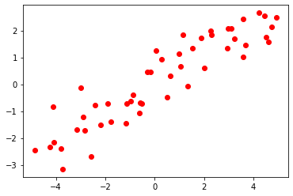

```python
# 产生数据
import numpy as np
import matplotlib.pyplot as plt
rnd=np.random.RandomState(38)
x=rnd.uniform(-5, 5, size=50)

# 向数据集添加噪音
y_no_noise = np.cos(6*x) +x
X = x.reshape(-1, 1)
y = (y_no_noise + rnd.normal(size=len(x)))/2

plt.plot(X, y, 'o', c='r')
plt.show()
```

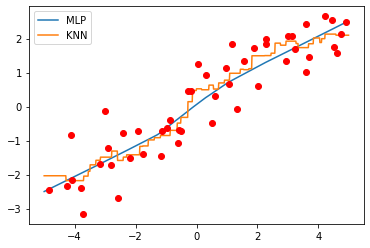

```python
# 分别使用 MLP 算法和 KNN 算法 对这个数据集进行回归分析

from sklearn.neural_network import MLPRegressor
from sklearn.neighbors import KNeighborsRegressor

# 生成一个等差数列
line=np.linspace(-5, 5, 1000, endpoint=False).reshape(-1, 1)
mlpr=MLPRegressor().fit(X, y)
knr=KNeighborsRegressor().fit(X, y)

plt.plot(line, mlpr.predict(line), label="MLP")
plt.plot(line, knr.predict(line), label="KNN")
plt.plot(X, y, 'o', c='r')
plt.legend(loc="best")
plt.show()

# 肉眼可见，MLP更平滑，而KNN覆盖更多的点。
# 该采用哪一个呢？
```

```python
# 对数据进行一下“装箱处理”(binning)，也称为“离散化处理”(discretization)

# 设置箱子个数11
bins=np.linspace(-5, 5, 11)
#将数据进行装箱处理
target_bin=np.digitize(X, bins=bins)
print("装箱范围:\n",bins)

print("前10个数据点的特征值:\n", X[:10])
print("前10个数据点的箱子:\n", target_bin[:10])
```

```
装箱范围:
 [-5. -4. -3. -2. -1.  0.  1.  2.  3.  4.  5.]
前10个数据点的特征值:
 [[-1.1522688 ]
 [ 3.59707847]
 [ 4.44199636]
 [ 2.02824894]
 [ 1.33634097]
 [ 1.05961282]
 [-2.99873157]
 [-1.12612112]
 [-2.41016836]
 [-4.25392719]]
前10个数据点的箱子:
 [[ 4]
 [ 9]
 [10]
 [ 8]
 [ 7]
 [ 7]
 [ 3]
 [ 4]
 [ 3]
 [ 1]]
```

### OneHotEncoder

```python
# sklearn 的 OneHotEncoder 和 pandas 的 get_dummies 功能基本一致，但是 OneHotEncoder 目前只能用于整型数值的类型变量。

from sklearn.preprocessing import OneHotEncoder
onehot = OneHotEncoder(sparse=False)
onehot.fit(target_bin)
X_in_bin=onehot.transform(target_bin)

print("装箱前的数据形态:\n", target_bin.shape ) #50行1列
print("装箱后的数据形态:\n", X_in_bin.shape ) #50行10列
print("装箱后的前10个数据点:\n", X_in_bin[:10])
```

```
装箱前的数据形态:
 (50, 1)
装箱后的数据形态:
 (50, 10)
装箱后的前10个数据点:
 [[0. 0. 0. 1. 0. 0. 0. 0. 0. 0.]
 [0. 0. 0. 0. 0. 0. 0. 0. 1. 0.]
 [0. 0. 0. 0. 0. 0. 0. 0. 0. 1.]
 [0. 0. 0. 0. 0. 0. 0. 1. 0. 0.]
 [0. 0. 0. 0. 0. 0. 1. 0. 0. 0.]
 [0. 0. 0. 0. 0. 0. 1. 0. 0. 0.]
 [0. 0. 1. 0. 0. 0. 0. 0. 0. 0.]
 [0. 0. 0. 1. 0. 0. 0. 0. 0. 0.]
 [0. 0. 1. 0. 0. 0. 0. 0. 0. 0.]
 [1. 0. 0. 0. 0. 0. 0. 0. 0. 0.]]
```

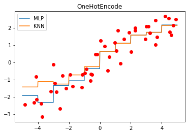

```python
# 分别使用 MLP 算法和 KNN 算法 对这个新数据集进行回归分析

# 使用独热编码进行数据表达
line2=onehot.transform(np.digitize(line, bins=bins))

mlpr2=MLPRegressor(max_iter=500).fit(X_in_bin, y)
knr2=KNeighborsRegressor().fit(X_in_bin, y)

plt.plot(line, mlpr2.predict(line2), label="MLP")
plt.plot(line, knr2.predict(line2), label="KNN")
plt.plot(X, y, 'o', c='r')
plt.legend(loc="best")
plt.title("OneHotEncode")
plt.show()

# 在x>0部分，2个拟合几乎完全重合。
# 对比 OneHotEncode 编码前，MLP回归模型变得更复杂；而KNN模型变得更简单。
```

装箱的好处：可以纠正模型过拟合或者欠拟合的问题。

- 尤其是对大规模高纬度的数据集使用线性模型的时候，装箱处理可以大幅提高线性模型的预测准确度。
- 装箱对于决策树算法没有太多作用，因为这类算法本身就是不停地拆分样本的特征数据，所以不需要再使用装箱操作。

# 数据“升维”

交叉式特征（Interaction Features）和多项式特征(Polynomial Features)

## 交叉式特征（Interaction Features）

```python
# 交叉式特征（Interaction Features） 就是在原始特征中添加交互项。

# 测试 np.hstack() 函数
import numpy as np
arr1=[1,2,3,4]
arr2=[10,30,40,50]
arr3=np.hstack( [arr1, arr2] )
arr3
```

```
array([ 1,  2,  3,  4, 10, 30, 40, 50])
```

```python
# 把原始数据和装箱后的数据堆叠
# 产生数据
import numpy as np
import matplotlib.pyplot as plt
rnd=np.random.RandomState(38)
x=rnd.uniform(-5, 5, size=50)

# 向数据集添加噪音
y_no_noise = np.cos(6*x) +x
X = x.reshape(-1, 1)
y = (y_no_noise + rnd.normal(size=len(x)))/2
print("X\n",X[:3])


# 对数据进行一下“装箱处理”(binning)，也称为“离散化处理”(discretization)
# 设置箱子个数11
bins=np.linspace(-5, 5, 11)
# 将数据进行装箱处理
target_bin = np.digitize(X, bins=bins)
print("\ntarget_bin\n",target_bin[:3])

# OneHotEncoder 只能输入整型
from sklearn.preprocessing import OneHotEncoder
onehot = OneHotEncoder(sparse=False)
onehot.fit(target_bin)
X_in_bin=onehot.transform(target_bin)
print("\nX_in_bin\n", X_in_bin[:3])

# 按列拼接
X_stack = np.hstack([X, X_in_bin])
print(X.shape, X_stack.shape) #(50, 1) (50, 11) 由1列，变为11列。后10列是编码后的。
```

```
X
 [[-1.1522688 ]
 [ 3.59707847]
 [ 4.44199636]]

target_bin
 [[ 4]
 [ 9]
 [10]]

X_in_bin
 [[0. 0. 0. 1. 0. 0. 0. 0. 0. 0.]
 [0. 0. 0. 0. 0. 0. 0. 0. 1. 0.]
 [0. 0. 0. 0. 0. 0. 0. 0. 0. 1.]]
(50, 1) (50, 11)
```

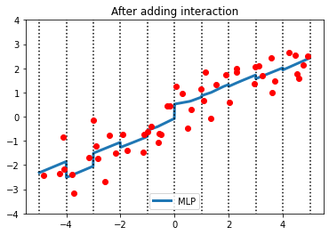

```python
# 分别使用 MLP 算法和 KNN 算法 对这个数据集进行回归分析

from sklearn.neural_network import MLPRegressor
from sklearn.neighbors import KNeighborsRegressor

# 生成一个等差数列
line=np.linspace(-5, 5, 1000, endpoint=False).reshape(-1, 1)
# 使用独热编码进行数据表达
line2=onehot.transform( np.digitize(line, bins=bins) )

#将数据进行堆叠
line_stack = np.hstack( [line, line2] )

# 训练数据
mlpr3=MLPRegressor().fit(X_stack, y)
knr3=KNeighborsRegressor().fit(X_stack, y)

# 绘图
plt.plot(line, mlpr3.predict(line_stack), linewidth=3, label="MLP")
#plt.plot(line, knr3.predict(line_stack), label="KNN")
plt.ylim(-4, 4)
for vline in bins:
    plt.plot([vline, vline], [-5, 5], ":", c='k')

plt.legend(loc="best")
plt.plot(X, y, 'o', c='r')

plt.title("After adding interaction")
plt.show()

# 每个数据所在的箱体中，MLP增加了斜率。
# 模型复杂度提高了。
```

### 交叉相

```python
# 每个箱体中的斜率基本一致了，但是这不是我们需要的。我们希望每个箱体都有各自的截距和斜率。
X_multi = np.hstack([X_in_bin, X*X_in_bin])
print(X.shape, X_in_bin.shape)

print(X_multi.shape) #(50, 20)
print(X_multi[0])
```

```
(50, 1) (50, 10)
(50, 20)
[ 0.         0.         0.         1.         0.         0.
  0.         0.         0.         0.        -0.        -0.
 -0.        -1.1522688 -0.        -0.        -0.        -0.
 -0.        -0.       ]
```

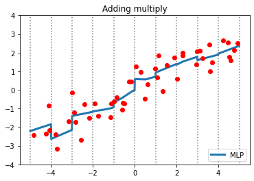

```python
# 每个箱子内都有自己的斜率

# 训练数据
mlpr4=MLPRegressor().fit(X_multi, y)
knr4=KNeighborsRegressor().fit(X_multi, y)

#将数据进行堆叠
line_multi = np.hstack( [line2, line * line2] )

# 绘图
plt.plot(line, mlpr4.predict(line_multi), linewidth=3, label="MLP")
#plt.plot(line, knr3.predict(line_stack), label="KNN")
plt.ylim(-4, 4)
for vline in bins:
    plt.plot([vline, vline], [-5, 5], ":", c='grey')

plt.plot(X, y, 'o', c='r')

plt.legend(loc="lower right")
plt.title("Adding multiply")
plt.show()

# 线性模型在低维度表现不好，在高纬度表现良好。所以可以升维后使用glm模型。
```

## 多项式特征(Polynomial Features)

多项式: y = a*x^4 + b*x^3 + c*x^2 + d*x + e

```python
# 导入多项式特征工具
from sklearn.preprocessing import PolynomialFeatures

# 向数据集添加多项式特征
poly=PolynomialFeatures(degree=20, include_bias=False)
X_poly = poly.fit_transform(X)

print(X.shape, X_poly.shape) #degree=20 就是变成20列
```

```
(50, 1) (50, 20)
```

```python
# 检验一下各项怎么来的, 第一个是1次方，第二个是2次方，类推。
print(X[0], np.power(X[0],2), np.power(X[0],[3, 4,5,6] ) )
print(X_poly[0])

print("\nfeature_names:\n", poly.get_feature_names_out())
```

```
[-1.1522688] [1.3277234] [-1.52989425  1.76284942 -2.0312764   2.34057643]
[ -1.1522688    1.3277234   -1.52989425   1.76284942  -2.0312764
   2.34057643  -2.6969732    3.10763809  -3.58083443   4.1260838
  -4.75435765   5.47829801  -6.3124719    7.27366446  -8.38121665
   9.65741449 -11.12793745  12.82237519 -14.77482293  17.02456756]

feature_names:
 ['x0' 'x0^2' 'x0^3' 'x0^4' 'x0^5' 'x0^6' 'x0^7' 'x0^8' 'x0^9' 'x0^10'
 'x0^11' 'x0^12' 'x0^13' 'x0^14' 'x0^15' 'x0^16' 'x0^17' 'x0^18' 'x0^19'
 'x0^20']
```

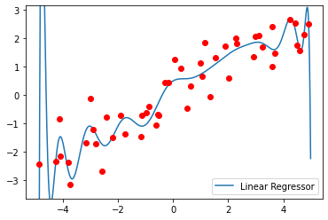

```python
# 尝试线性回归
from sklearn.linear_model import LinearRegression
lr_poly = LinearRegression().fit(X_poly, y)

line_poly = poly.transform(line)

# 绘制图形
plt.plot(line, lr_poly.predict(line_poly), label="Linear Regressor")
plt.xlim(np.min(X)-0.5, np.max(X)+0.5)
plt.ylim(np.min(y)-0.5, np.max(y)+0.5)
plt.plot(X, y, 'o', c='r')
plt.legend(loc="lower right")
plt.show()

# 这个线性拟合可不是直线！低维数据集，线性拟合通常欠拟合，但是进行多项式扩展后，可以一定程度解决欠拟合问题。

# 除了将特征转为多项式的方法之外，我们还可以用类似正弦函数 sin(), 对数函数 log(), 或指数函数 exp() 等来进行相似的操作。
```

# 自动特征选择

## 单一变量法进行特征选择

很多场景只关心最重要的指标，忽略其他不那么重要的指标：

- 玩具厂，根据年龄划分产品
- 金融公司，根据收入流水确定目标人群的偿债能力

sklearn 中的特征选择方法：

- SelectPercentile: 按照百分比选择特征
- SelectKBest: 选择最重要的K个指标

```python
# 导入某天中国A股全部股票交易信息
# 上交所: http://www.sse.com.cn/market/price/report/
# 深交所: http://www.szse.cn/market/trend/index.html


# (1) 获取原始json数据
import time
timestamp=str(round(time.time()*1000))
begin=str(0)
end=str(2060) #1515

# http://www.sse.com.cn/market/price/report/
url="http://yunhq.sse.com.cn:32041/v1/sh1/list/exchange/equity?callback=jQuery111208015895779126387_1560941576071&select=date%2Ccode%2Cname%2Copen%2Chigh%2Clow%2Clast%2Cprev_close%2Cchg_rate%2Cvolume%2Camount%2Ctradephase%2Cchange%2Camp_rate%2Ccpxxsubtype%2Ccpxxprodusta&order=&begin="+begin+"&end="+end+"&_="+timestamp;
print("url=", url)

headers = {
  'User-Agent': 'Mozilla/5.0 (Macintosh; Intel Mac OS X 10_13_2) AppleWebKit/537.36 (KHTML, like Gecko) Chrome/65.0.3325.162 Safari/537.36',
  'Referer': 'http://www.sse.com.cn/market/price/report/'
}

import requests
r = requests.get(url, headers=headers) #, auth=('user', 'pass')
#rs1=r.status_code #200
#rs2=r.headers['content-type'] #'text/html; charset=utf-8'
#rs3=r.encoding #'utf-8' 编码，修改编码
rs4=r.text
#r.json() #只有r.headers['content-type']为json时才能用。否则报错。
#print(rs1,rs2,rs3,"\n")
#rs4 #现在是字符串格式

# (2) 解析json格式为python数组
import json,re
#json
rs=re.sub(r"jQuery111208015895779126387_1560941576071\(", "", rs4)
rs=re.sub(r"\)$", "", rs)
rs=eval(rs)
print( len(rs['list']) )  #25

# (3) 注释每一列的字段名
# select: code,name,open,high,low,last,prev_close,chg_rate,volume,amount,tradephase,change,amp_rate
print('date code,name,open,high,low,last,prev_close,chg_rate,volume,amount,tradephase,change,amp_rate cpxxsubtype cpxxprodusta')
titles='date,code,name,open,high,low,last,prev_close,chg_rate,volume,amount,tradephase,change,amp_rate,cpxxsubtype,cpxxprodusta'.split(",")

#data
alists=rs['list']
#len(alist) #1515
print(alists[0])

alist=alists[0]
for i in range(len(titles)):
    print(i, titles[i], "=", alist[i])

import numpy as np
alists2=np.array(alists)
print(alists2.shape) #(2050, 13)

import pandas as pd
stock=pd.DataFrame(alists2, columns=titles)
stock.head()

# 涨跌幅 chg_rate(%)
# 振幅 amp_rate
```

```
url= http://yunhq.sse.com.cn:32041/v1/sh1/list/exchange/equity?callback=jQuery111208015895779126387_1560941576071&select=date%2Ccode%2Cname%2Copen%2Chigh%2Clow%2Clast%2Cprev_close%2Cchg_rate%2Cvolume%2Camount%2Ctradephase%2Cchange%2Camp_rate%2Ccpxxsubtype%2Ccpxxprodusta&order=&begin=0&end=2060&_=163…
2050
date code,name,open,high,low,last,prev_close,chg_rate,volume,amount,tradephase,change,amp_rate cpxxsubtype cpxxprodusta
[20211115, '600000', '浦发银行', 8.66, 8.75, 8.65, 8.75, 8.65, 1.16, 27625801, 240602624, 'E110', 0.1, 1.16, 'ASH', '   D  F  N          ']
0 date = 20211115
1 code = 600000
2 name = 浦发银行
3 open = 8.66
4 high = 8.75
5 low = 8.65
6 last = 8.75
7 prev_close = 8.65
8 chg_rate = 1.16
9 volume = 27625801
10 amount = 240602624
11 tradephase = E110
12 change = 0.1
13 amp_rate = 1.16
14 cpxxsubtype = ASH
15 cpxxprodusta =    D  F  N
(2050, 16)
```

|  | date | code | name | open | high | low | last | prev_close | chg_rate | volume | amount | tradephase | change | amp_rate | cpxxsubtype | cpxxprodusta |
| --- | --- | --- | --- | --- | --- | --- | --- | --- | --- | --- | --- | --- | --- | --- | --- | --- |
| 0 | 20211115 | 600000 | 浦发银行 | 8.66 | 8.75 | 8.65 | 8.75 | 8.65 | 1.16 | 27625801 | 240602624 | E110 | 0.1 | 1.16 | ASH | D F N |
| 1 | 20211115 | 600004 | 白云机场 | 12.65 | 12.71 | 12.5 | 12.51 | 12.73 | -1.73 | 13532530 | 170390064 | E110 | -0.22 | 1.65 | ASH | D F N |
| 2 | 20211115 | 600006 | 东风汽车 | 7.07 | 7.16 | 6.9 | 6.94 | 7.09 | -2.12 | 32560993 | 227359342 | E110 | -0.15 | 3.67 | ASH | D F N |
| 3 | 20211115 | 600007 | 中国国贸 | 14.6 | 14.9 | 14.25 | 14.81 | 14.6 | 1.44 | 5293865 | 77362085 | E110 | 0.21 | 4.45 | ASH | D F N |
| 4 | 20211115 | 600008 | 首创环保 | 3.18 | 3.22 | 3.15 | 3.21 | 3.19 | 0.63 | 79820965 | 254427365 | E110 | 0.02 | 2.19 | ASH | D F N |

```python
print(stock["cpxxsubtype"].unique())
print(stock["cpxxprodusta"].unique())
```

```
['ASH' 'KSH' 'BSH']
['   D  F  N          ' '   S  F  N          ' '   D  FU N          '
 'N  D  F  N          ' '   D  F WN          ' '   D  FUWN          '
 '   DY F WN          ']
```

```python
tmp=stock["chg_rate"].astype(float)
print(tmp.min(), "\t", tmp.max())

tmp=stock["amp_rate"].astype(float)
print(tmp.min(), "\t", tmp.max())
```

```
-10.31 	 71.16
0.0 	 37.82
```

```python
# target 涨幅列
y=stock['chg_rate'].astype(float)
print(y.shape)
y[0]
```

```
(2050,)
```

```
1.16
```

```python
# 特征
features = stock.loc[:, 'open,high,low,last,prev_close,volume,amount,change,amp_rate'.split(",")].astype(float)
X=features.values

print(X.shape)
X[:1]
```

```
(2050, 9)
```

```
array([[8.66000000e+00, 8.75000000e+00, 8.65000000e+00, 8.75000000e+00,
        8.65000000e+00, 2.76258010e+07, 2.40602624e+08, 1.00000000e-01,
        1.16000000e+00]])
```

```python
# 由于各个列差异较大，需要标准化

from sklearn.model_selection import train_test_split
X_train, X_test, y_train, y_test = train_test_split(X, y, random_state=62)

# 数据预处理
from sklearn.preprocessing import StandardScaler
scaler = StandardScaler()
scaler.fit(X_train)
X_train_scaled=scaler.transform(X_train)
X_test_scaled=scaler.transform(X_test)

# 设置神经网络层数和alpha
from sklearn.neural_network import MLPRegressor
mlpr=MLPRegressor(random_state=62, hidden_layer_sizes=[100,100], alpha=0.001, max_iter=500)
mlpr.fit(X_train_scaled, y_train)

# 打分
print("training set:{:0.3f}".format( mlpr.score(X_train_scaled, y_train)) )
print("tesing set:{:0.3f}".format( mlpr.score(X_test_scaled, y_test)) )

# 打分挺高了
```

```
training set:0.992
tesing set:0.982
```

```python
# 列举涨跌幅>=10%
wanted=stock.loc[:, ("date","code","name", "last", "prev_close", "chg_rate")]
print("涨停榜\n", wanted[y>=9].sort_values(by=['chg_rate', "last"], ascending=[False,True] ))

print("\n跌停榜\n", wanted[y<= -9].sort_values(by=['chg_rate', "last"], ascending=[False,True] ))
```

```
涨停榜
           date    code    name    last prev_close chg_rate
515   20211115  600640   新国脉     14.86      13.51     9.99
1110  20211115  603138    海量数据   18.71      17.01     9.99
1612  20211115  605300    佳禾食品   21.13      19.21     9.99
470   20211115  600587    新华医疗    22.8      20.73     9.99
1617  20211115  605333    沪光股份   24.77      22.52     9.99
1604  20211115  605277    新亚电子    37.1      33.73     9.99
1056  20211115  603050    科林电气   19.28      17.53     9.98
1176  20211115  603286    日盈电子   19.51      17.74     9.98
1453  20211115  603869    新智认知    9.92       9.02     9.98
312   20211115  600379    宝光股份   12.46      11.33     9.97
1312  20211115  603603    博天环境     7.4       6.73     9.96
175   20211115  600215    长春经开    9.16       8.33     9.96
1231  20211115  603377    东方时尚    9.28       8.44     9.95
```

[output cut: 52 more lines]

### 使用 SelectPercentile 进行特征选择

```python
from sklearn.feature_selection import SelectPercentile
#设置特征选择参数
select = SelectPercentile(percentile=50)
select.fit(X_train_scaled, y_train)
X_train_selected = select.transform(X_train_scaled)

# 输出维度
print(X_train_scaled.shape, X_train_selected.shape) #9列变为4列

# 查看哪些被保留了
mask=select.get_support()
print(mask)
```

```
(1537, 9) (1537, 4)
[False False False False False  True  True  True  True]
```

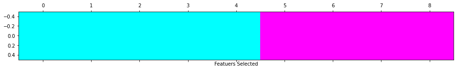

```python
# 使用图像表示特征选择的结果
import matplotlib.pyplot as plt
plt.matshow(mask.reshape(1,-1), cmap=plt.cm.cool)
plt.xlabel("Featuers Selected")
plt.show() # 红色是保留的。
```

```python
# 再次使用选择的特征，训练神经网络
X_test_selected=select.transform(X_test_scaled)

# 设置神经网络层数和alpha
from sklearn.neural_network import MLPRegressor
mlpr_sp=MLPRegressor(random_state=62, hidden_layer_sizes=[100,100], alpha=0.001, max_iter=500)
mlpr_sp.fit(X_train_selected, y_train)

# 打分
print("training set:{:0.3f}".format( mlpr_sp.score(X_train_selected, y_train)) )
print("tesing set:{:0.3f}".format( mlpr_sp.score(X_test_selected, y_test)) )

# 打分降低了。
# 说明我们的数据不包括噪音，去掉的都是有用的信息。

# 单一变量法进行特征筛选，不依赖于具体建模的算法。
```

```
training set:0.974
tesing set:0.943
```

## 基于模型的特征选择

步骤：先使用一个监督学习模型，判断数据特征的重要性，保留最重要的特征。

- 这一步使用的模型和最终使用的不一定一样。

```python
# 导入基于模型选择特征的工具
from sklearn.feature_selection import SelectFromModel

# 导入随机森林模型
from sklearn.ensemble import RandomForestRegressor

# 设置模型 n_estimators 参数
sfm=SelectFromModel(RandomForestRegressor(n_estimators=100, random_state=38), threshold="median")

# 使用模型拟合数据
sfm.fit(X_train_scaled, y_train)
X_train_sfm =sfm.transform(X_train_scaled)

# 打印形状
print(X_train_scaled.shape, X_train_sfm.shape) #9列变5列


# 查看哪些被保留了
mask_sfm=sfm.get_support()
print(mask_sfm)
```

```
(1537, 9) (1537, 5)
[ True False False False  True  True False  True  True]
```

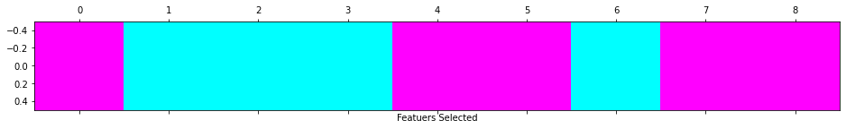

```python
# 使用图像表示特征选择的结果
import matplotlib.pyplot as plt
plt.matshow(mask_sfm.reshape(1,-1), cmap=plt.cm.cool)
plt.xlabel("Featuers Selected")
plt.show()

# 红色是保留的。随机森林法 和 单一变量法，选择的特征不同。
```

```python
# 再次使用选择的特征，训练神经网络
X_test_sfm=sfm.transform(X_test_scaled)

# 设置神经网络层数和alpha
from sklearn.neural_network import MLPRegressor
mlpr_sfm=MLPRegressor(random_state=62, hidden_layer_sizes=[100,100], alpha=0.001, max_iter=500)
mlpr_sfm.fit(X_train_sfm, y_train)

# 打分
print("training set:{:0.3f}".format( mlpr_sfm.score(X_train_sfm, y_train)) )
print("tesing set:{:0.3f}".format( mlpr_sfm.score(X_test_sfm, y_test)) )

# 打分比原始的降低了。但是比单一变量法略高。
# 说明我们的数据不包括噪音，去掉的都是有用的信息。
```

```
training set:0.989
tesing set:0.976
```

## 迭代式特征选择

递归特征剔除法(Recursive Feature Elimination, RFE): https://machinelearningmastery.com/rfe-feature-selection-in-python/

- 使用某个模型对特征进行筛选，之后建立2个模型，去掉某个特征前后的模型，

```python
from sklearn.feature_selection import RFE
rfe=RFE(RandomForestRegressor(n_estimators=100, random_state=38), n_features_to_select=5)

rfe.fit(X_train_scaled, y_train)
mask=rfe.get_support()
mask
```

```
array([ True, False,  True, False,  True, False, False,  True,  True])
```

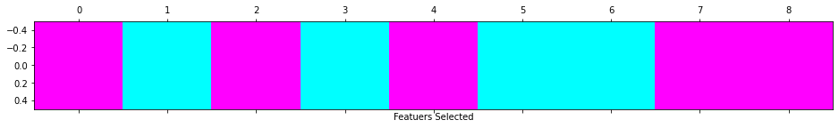

```python
# 使用图像表示特征选择的结果
import matplotlib.pyplot as plt
plt.matshow(mask.reshape(1,-1), cmap=plt.cm.cool)
plt.xlabel("Featuers Selected")
plt.show()
```

```python
# 再次使用选择的特征，训练神经网络
X_train_rfe=rfe.transform(X_train_scaled)
X_test_rfe=rfe.transform(X_test_scaled)

# 设置神经网络层数和alpha
from sklearn.neural_network import MLPRegressor
mlpr_rfe=MLPRegressor(random_state=62, hidden_layer_sizes=[100,100], alpha=0.001, max_iter=500)
mlpr_rfe.fit(X_train_rfe, y_train)

# 打分
print("training set:{:0.3f}".format( mlpr_rfe.score(X_train_rfe, y_train)) )
print("tesing set:{:0.3f}".format( mlpr_rfe.score(X_test_rfe, y_test)) )

# 打分比原始的略高，最好的结果了。
```

```
training set:0.992
tesing set:0.986
```